# 시험4(190814)

## 1. 다음과 같은 어레이를 Numpy를 이용하여 만드시오.

### 1-1 [0., 0.5, 1., 1.5, 2., 2.5, 3., 3.5, 4., 4.5]

```python
import numpy as np
```

```python
np.arange(0, 5, 0.5)
```

```
array([0. , 0.5, 1. , 1.5, 2. , 2.5, 3. , 3.5, 4. , 4.5])
```

### 1-2 [[1, 2, 3, 4, 5],

### [6, 7, 8, 9, 10]]

```python
np.arange(1, 11).reshape(2, 5)
```

```
array([[ 1,  2,  3,  4,  5],
       [ 6,  7,  8,  9, 10]])
```

### 1-3 [[1, 0, 0],

### [0, 1, 0],

### [0, 0, 1]]

```python
np.identity(n=3, dtype=np.int8)
```

```
array([[1, 0, 0],
       [0, 1, 0],
       [0, 0, 1]], dtype=int8)
```

### 1-4 [[1, 1, 1, 1],

### [1, 1, 1, 1],

### [1, 1, 1, 1],

### [1, 1, 1, 1]]

```python
np.ones((4,4), dtype=np.int32)
```

```
array([[1, 1, 1, 1],
       [1, 1, 1, 1],
       [1, 1, 1, 1],
       [1, 1, 1, 1]])
```

### 1-5 [[1, 3, 5, 7],

### [9, 11, 13, 15],

### [17, 19, 21, 23]]

```python
np.arange(1, 24, 2).reshape(3, 4)
```

```
array([[ 1,  3,  5,  7],
       [ 9, 11, 13, 15],
       [17, 19, 21, 23]])
```

## 2. 다음과 같은 데이터프레임을 만드시오

```python
import numpy as np
import pandas as pd
```

```python
data = {
    "2015": [9904312, 3448737, 2890451, 2466052],
    "2010": [9631482, 3393191, 2632035, 2431774],
    "2005": [9762546, 3512547, 2517680, 2456016],
    "2000": [9853972, 3655437, 2466338, 2473990],
    "지역": ["수도권", "경상권", "수도권", "경상권"],
    "2010-2015 증가율": [0.0283, 0.0163, 0.0982, 0.0141]
}
columns = ["지역", "2015", "2010", "2005", "2000", "2010-2015 증가율"]
index = ["서울", "부산", "인천", "대구"]
df = pd.DataFrame(data, index=index, columns=columns)
df
```

|  | 지역 | 2015 | 2010 | 2005 | 2000 | 2010-2015 증가율 |
| --- | --- | --- | --- | --- | --- | --- |
| 서울 | 수도권 | 9904312 | 9631482 | 9762546 | 9853972 | 0.0283 |
| 부산 | 경상권 | 3448737 | 3393191 | 3512547 | 3655437 | 0.0163 |
| 인천 | 수도권 | 2890451 | 2632035 | 2517680 | 2466338 | 0.0982 |
| 대구 | 경상권 | 2466052 | 2431774 | 2456016 | 2473990 | 0.0141 |

## 3. 타이타닉호 승객에 대해서 다음을 구하시오.

### 3-1 성별(sex) 인원수, 선실별(class) 인원수, 사망/생존(alive) 인원수를 구하시오.

```python
import seaborn as sns
titanic = sns.load_dataset("titanic")
```

```python
titanic.sex.value_counts()
```

```
male      577
female    314
Name: sex, dtype: int64
```

```python
titanic.age.value_counts().head()
```

```
24.0    30
22.0    27
18.0    26
19.0    25
30.0    25
Name: age, dtype: int64
```

```python
titanic['class'].value_counts()
```

```
Third     491
First     216
Second    184
Name: class, dtype: int64
```

```python
titanic.alive.value_counts()
```

```
no     549
yes    342
Name: alive, dtype: int64
```

### 3-2 '미성년자', '청년', '중년', '장년', '노년' 승객의 비율을 구하시오. 단 나이의 기준은 [1, 15, 30, 45, 60, 99] 임.

```python
bins = [1, 15, 30, 45, 60, 99]
labels = ["미성년자", "청년", "중년", "장년", "노년"]
```

```python
titanic_alive = titanic[titanic.survived == 1]['age']
titanic_dead = titanic[titanic.survived == 0]['age']
alive_ = pd.cut(titanic_alive, bins, labels=labels)
alive_.dropna(inplace = True)
dead_ = pd.cut(titanic_dead, bins, labels=labels)
dead_.dropna(inplace = True)
```

```python
pd.value_counts(alive_)/sum(pd.value_counts(alive_))
```

```
청년      0.420863
중년      0.309353
미성년자    0.133094
장년      0.118705
노년      0.017986
Name: age, dtype: float64
```

```python
pd.value_counts(dead_)/sum(pd.value_counts(dead_))
```

```
청년      0.495261
중년      0.274882
장년      0.113744
미성년자    0.075829
노년      0.040284
Name: age, dtype: float64
```

## 4. 팁 데이터에 대해서 다음을 구하시오

### 4-1 팁의 비율(단위 %)을 소숫점 2째자리까지 구하시오.

```python
tips = sns.load_dataset("tips")
```

```python
tips['tip_pct'] = (tips['tip'] / tips['total_bill'] * 100).round(2)
tips.tail()
```

|  | total_bill | tip | sex | smoker | day | time | size | tip_pct |
| --- | --- | --- | --- | --- | --- | --- | --- | --- |
| 239 | 29.03 | 5.92 | Male | No | Sat | Dinner | 3 | 20.39 |
| 240 | 27.18 | 2.00 | Female | Yes | Sat | Dinner | 2 | 7.36 |
| 241 | 22.67 | 2.00 | Male | Yes | Sat | Dinner | 2 | 8.82 |
| 242 | 17.82 | 1.75 | Male | No | Sat | Dinner | 2 | 9.82 |
| 243 | 18.78 | 3.00 | Female | No | Thur | Dinner | 2 | 15.97 |

### 4-2 팁의 비율이 가장 높은 날은 목, 금, 토, 일요일 중 어떤 날인지 피봇 테이블을 이용하여 구하시오.

```python
import seaborn as sns
tips = sns.load_dataset("tips")
tips['tip_pct'] = (tips['tip'] / tips['total_bill'] * 100).round(2)
tips.tail()
```

|  | total_bill | tip | sex | smoker | day | time | size | tip_pct |
| --- | --- | --- | --- | --- | --- | --- | --- | --- |
| 239 | 29.03 | 5.92 | Male | No | Sat | Dinner | 3 | 20.39 |
| 240 | 27.18 | 2.00 | Female | Yes | Sat | Dinner | 2 | 7.36 |
| 241 | 22.67 | 2.00 | Male | Yes | Sat | Dinner | 2 | 8.82 |
| 242 | 17.82 | 1.75 | Male | No | Sat | Dinner | 2 | 9.82 |
| 243 | 18.78 | 3.00 | Female | No | Thur | Dinner | 2 | 15.97 |

```python
tips.pivot_table('tip_pct','day')
```

| day | tip_pct |
| --- | --- |
| Thur | 16.126452 |
| Fri | 16.991579 |
| Sat | 15.314598 |
| Sun | 16.689605 |

## 5. 다음의 지시대로 SQLite3를 이용하는 파이썬 프로그램을 작성하시오.

### 5-1 필드로 [백넘버(PK), 이름, 포지션]을 갖는 테이블 Eagles를 생성

```python
import sqlite3
```

```python
conn = sqlite3.connect('./test.db')
'''
conn = sqlite3.connect(':memory:')    # 메모리 DB 접속(일회성)
'''
```

```
"\nconn = sqlite3.connect(':memory:')    # 메모리 DB 접속(일회성)\n"
```

```python
cur = conn.cursor()
cur.execute('CREATE TABLE IF NOT EXISTS Eagles \
    (back_no INT NOT NULL, \
     name TEXT, \
     position TEXT, \
     PRIMARY KEY(back_no));')
conn.commit()
```

[output not shown]

### 5-2 1)번에서 만든 테이블에 (8, 정근우, 내야수)를 포함하여 임의로 5명의 선수를 삽입

```python
cur = conn.cursor()
cur.execute("INSERT INTO Eagles VALUES \
    (8, '정근우', '내야수'), \
    (1, '하주석', '내야수'), \
    (52, '김태균', '내야수'), \
    (30, '호잉', '외야수'), \
    (28, '양성우', '외야수');")
```

```
<sqlite3.Cursor at 0xb48fab0>
```

```python
conn.commit()
```

### 5-3 2)번에서 입력한 선수 모두를 보여주는 프로그램

```python
cur = conn.cursor()
cur.execute('SELECT * FROM Eagles')
for row in cur:
    print(row)
```

```
(8, '정근우', '내야수')
(1, '하주석', '내야수')
(52, '김태균', '내야수')
(30, '호잉', '외야수')
(28, '양성우', '외야수')
```

### 5-4 정근우 선수의 포지션을 외야수로 변경

```python
cur = conn.cursor()
sql = "UPDATE Eagles SET position='외야수' WHERE back_no=8;"
cur.execute(sql)
conn.commit()

sql = 'SELECT * FROM Eagles WHERE back_no=8;'
cur.execute(sql)
row = cur.fetchone()
print(row)
```

```
(8, '정근우', '외야수')
```

```python
cur = conn.cursor()
sql = 'SELECT back_no FROM Eagles ORDER BY back_no DESC LIMIT 1;'
cur.execute(sql)
max_no = cur.fetchone()
max_no
```

[output not shown]

## 6. 시그모이드 함수 (sigmoid(x) = 1 / (1 + np.exp(-x)))와 시그모이드 함수를 미분한 함수(sigmoid(x) * (1 - sigmoid(x))의 그래프를 그리시오.(단, x의 범위는 -3에서 +3까지))

```python
import numpy as np
import matplotlib.pyplot as plt
%matplotlib inline
```

```python
def sigmoid(x):
    return 1/(1 + np.exp(-x))
def deri_sig(x):
    return sigmoid(x) * (1-sigmoid(x))
```

```python
X = np.linspace(-3, 3, 1001)
```

```python
derivative_Y = derivative_sigmoid(X)
```

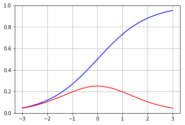

```python
plt.plot(X, sig_Y, color='b')
plt.plot(X, derivative_Y, color='r')
plt.grid()
plt.show()
```

## 7. 다음의 빈 칸에 들어갈 말은?

### 7-5 딥 러닝에서 입력층과 출력층 사이의 층을 ( 은닉층 ) 이라 한다.

## 8. 아이리스 데이터의 4가지 속성(꽃받침 길이/폭, 꽃잎 길이/폭)을 이용하여 품종을 예측(단, 정확도는 98% 이상일 것)

```python
iris = sns.load_dataset("iris")
iris.tail()
```

|  | sepal_length | sepal_width | petal_length | petal_width | species |
| --- | --- | --- | --- | --- | --- |
| 145 | 6.7 | 3.0 | 5.2 | 2.3 | virginica |
| 146 | 6.3 | 2.5 | 5.0 | 1.9 | virginica |
| 147 | 6.5 | 3.0 | 5.2 | 2.0 | virginica |
| 148 | 6.2 | 3.4 | 5.4 | 2.3 | virginica |
| 149 | 5.9 | 3.0 | 5.1 | 1.8 | virginica |

```python
from keras.utils import np_utils
from sklearn.preprocessing import LabelEncoder
dataset = iris.values
X = dataset[:,0:4].astype(float)
Y_obj = dataset[:,4]

e = LabelEncoder()
e.fit(Y_obj)
Y = e.transform(Y_obj)
Y = np_utils.to_categorical(Y, 3)
```

```python
import tensorflow as tf
from keras.models import Sequential
from keras.layers.core import Dense

seed = 0
tf.set_random_seed(seed)
```

```python
# 모델의 설정
model = Sequential()
model.add(Dense(12, input_dim=4, activation='relu'))
model.add(Dense(8, activation='relu'))
model.add(Dense(3, activation='softmax'))
# 모델 컴파일
model.compile(loss='categorical_crossentropy',
              optimizer='adam',
              metrics=['accuracy'])
```

```python
# 모델 실행
model.fit(X, Y, epochs=100, batch_size=10)
```

```
<keras.callbacks.History at 0x143456d8>
```

```python
print("\n Accuracy: %.4f" % (model.evaluate(X, Y)[1]))
```

```
 Accuracy: 0.9733
```

## 9. 피마 인디언 데이터의 8가지 속성을 이용하여 당뇨병 여부를 판단할 것(단, 데이터의 25%는 테스트 데이터로 사용하여 정확도를 구할 것)

```python
df = pd.read_csv('D:/Workspace/Deep-Learning/dataset/pima-indians-diabetes.csv',
                 names = ["pregnant", "plasma", "pressure", "thickness",
                 "insulin", "BMI", "pedigree", "age", "class"])
df.head()
```

|  | pregnant | plasma | pressure | thickness | insulin | BMI | pedigree | age | class |
| --- | --- | --- | --- | --- | --- | --- | --- | --- | --- |
| 0 | 6 | 148 | 72 | 35 | 0 | 33.6 | 0.627 | 50 | 1 |
| 1 | 1 | 85 | 66 | 29 | 0 | 26.6 | 0.351 | 31 | 0 |
| 2 | 8 | 183 | 64 | 0 | 0 | 23.3 | 0.672 | 32 | 1 |
| 3 | 1 | 89 | 66 | 23 | 94 | 28.1 | 0.167 | 21 | 0 |
| 4 | 0 | 137 | 40 | 35 | 168 | 43.1 | 2.288 | 33 | 1 |

```python
seed = 0
np.random.seed(seed)
tf.set_random_seed(seed)
```

```python
from sklearn.model_selection import train_test_split
dataset = np.loadtxt("D:/Workspace/Deep-Learning/dataset/pima-indians-diabetes.csv", delimiter=",")
X = dataset[:,0:8]
Y = dataset[:,8]
X_train, X_test, Y_train, Y_test = train_test_split(X, Y, test_size=0.25,
                                                    random_state=seed)
```

```python
model = Sequential()
model.add(Dense(12, input_dim=8, activation='relu'))
model.add(Dense(8, activation='relu'))
model.add(Dense(1, activation='sigmoid'))
```

```python
model.compile(loss='binary_crossentropy',
              optimizer='adam',
              metrics=['accuracy'])
```

```python
model.fit(X_train, Y_train, epochs=200, batch_size=10)
```

```
<keras.callbacks.History at 0x149c7320>
```

```python
print("\n Accuracy: %.4f" % (model.evaluate(X_test, Y_test)[1]))
```

```
 Accuracy: 0.7708
```